# Data Wrangling and Visualization

## 9.3 Analysis of Physical Activity Total

### 9.3.1 Analysis of Physical Activity by Gender

```r
gender_PA <- can_path_merged %>%
  group_by(Gender_recode) %>%
  summarise(mean_PA = mean(PA_total_short))

gender_PA
```

```
## # A tibble: 2 × 2
##   Gender_recode mean_PA
##   <fct>           <dbl>
## 1 Female          2536.
## 2 Male            2703.
```

### Boxplot of Physical Activity by Gender

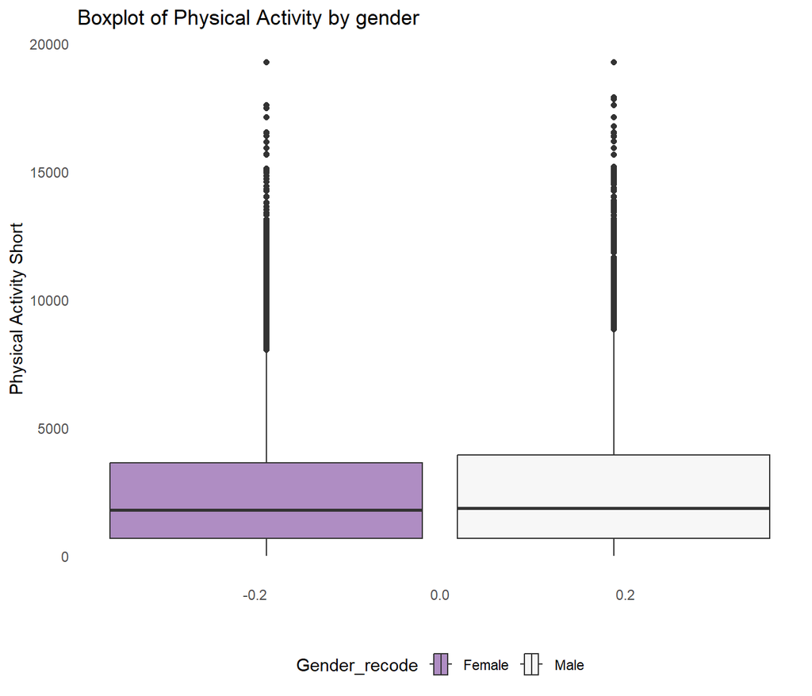

```r
ggplot(can_path_merged, aes(x = PA_total_short, fill = Gender_recode))+
  geom_boxplot()+
  scale_fill_brewer(palette = "PRGn")+
  coord_flip()+
  labs(title = "Boxplot of Physical Activity by gender",
       x = "Physical Activity Short",
       y= "")+
  theme_minimal()+
  theme(panel.grid.major = element_blank(), panel.grid.minor = element_blank(),
        legend.position = "bottom")
```

### 9.3.2. Analysis of Physical Activity by income category

```r
Income_PA <- can_path_merged %>%
  group_by(Income_recode) %>%
  summarise(mean_PA= mean(PA_total_short)) %>%
  arrange(desc(mean_PA))

Income_PA
```

```
## # A tibble: 8 × 2
##   Income_recode         mean_PA
##   <fct>                   <dbl>
## 1 200 000 $ or more       2903.
## 2 150 000 $ - 199 999 $   2652.
## 3 25 000 $ - 49 999 $     2615.
## 4 50 000 $ - 74 999 $     2578.
## 5 100 000 $ - 149 999 $   2575.
## 6 75 000 $ - 99 999 $     2560.
## 7 Less than 10 000 $      2513.
## 8 10 000 $ - 24 999 $     2452.
```

### Boxplot of Physical Activity by income category

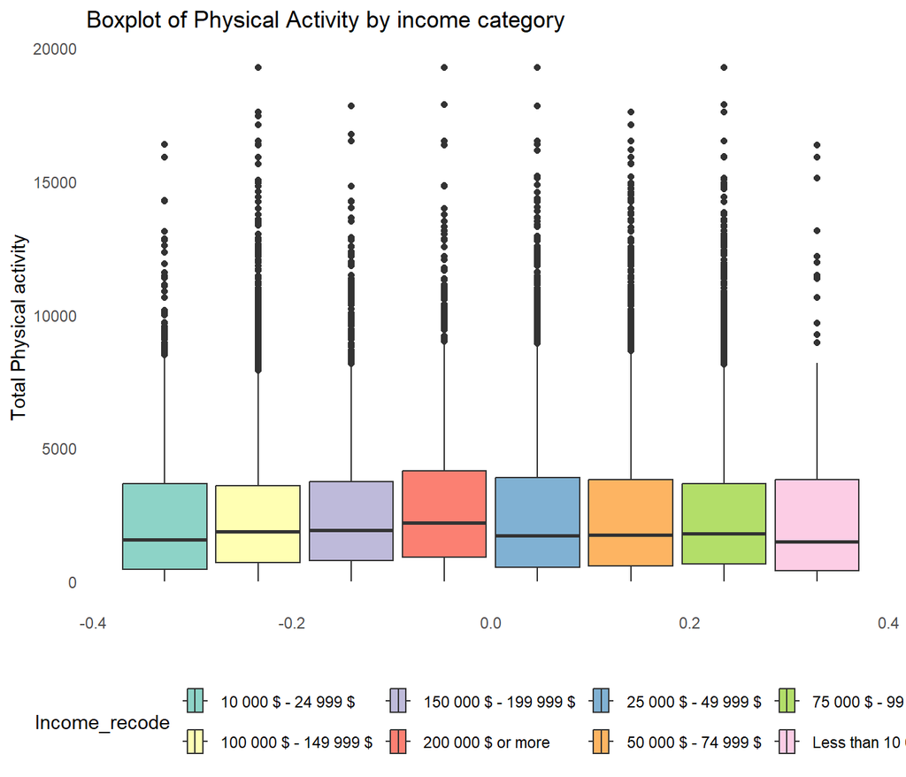

```r
ggplot(can_path_merged, aes(x = PA_total_short, fill = Income_recode))+
  geom_boxplot()+
  scale_fill_brewer(palette = "Set3")+
  coord_flip()+
  labs(title = "Boxplot of Physical Activity by income category",
       x = "Total Physical activity ",
       y= "")+
  theme_minimal()+
  theme(panel.grid.major = element_blank(), panel.grid.minor = element_blank(),
        legend.position = "bottom")
```

The boxplot compares total physical activity across income categories. Higher income classes, like “$200,000 or more,” register a higher median activity level versus lower income classes. Variability-the IQR-is consistent across all categories, with significant outliers in each category.

### 9.3.3 Analysis of Physical Activity Total by Health status

```r
health_PA <- can_path_merged %>%
  group_by(Gen_health_recode) %>%
  summarise(mean_PA = mean(PA_total_short)) %>%
  arrange(desc(mean_PA))

health_PA
```

```
## # A tibble: 5 × 2
##   Gen_health_recode mean_PA
##   <fct>               <dbl>
## 1 Excellent           3224.
## 2 Very good           2723.
## 3 Good                2313.
## 4 Fair                1927.
## 5 Poor                1743.
```

From the table, physical activity increases with improved self-reported health. The “Excellent” health group has the highest average activity, 3224.49, while the , “Poor,” reported the lowest, 1743.37.

### chart of Physical Activity by health status

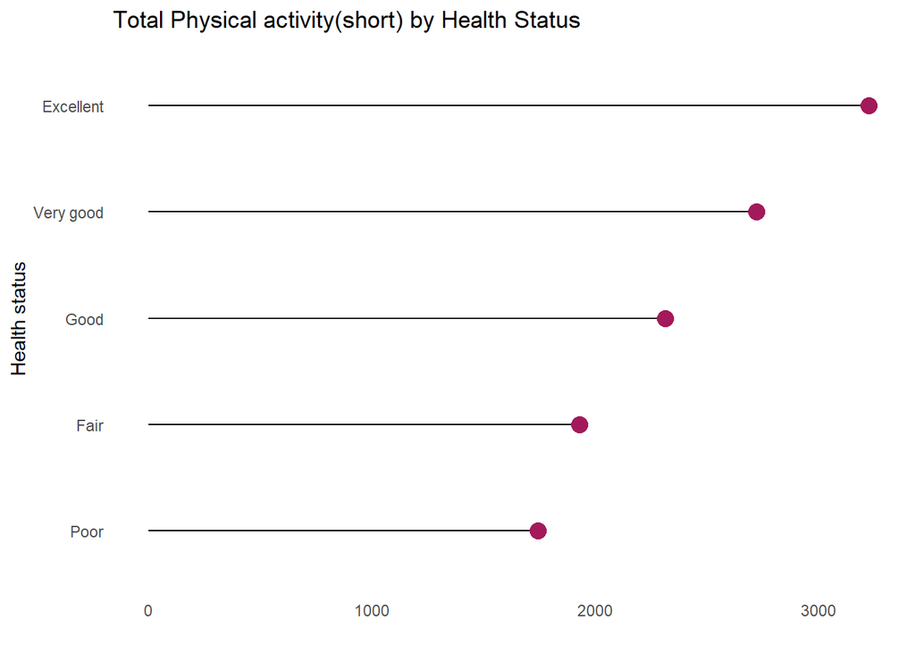

```r
ggplot(data = health_PA, aes(x = reorder(Gen_health_recode, mean_PA), y= mean_PA))+
  geom_segment(aes(x = reorder(Gen_health_recode, mean_PA), yend= mean_PA, xend =reorder(Gen_health_recode, mean_PA), y = 0 ))+
  geom_point( color = "#a31a5a", size = 4)+
  scale_fill_brewer( palette = "Set3")+
  labs(title = "Total Physical activity(short) by Health Status",
       x = "Health status",
       y= "")+
  theme_minimal()+
  theme(panel.grid.major = element_blank(), panel.grid.minor = element_blank(),
        legend.position = "bottom")+
  coord_flip()
```

Physical activity levels are high among excellent groups and reduces as health status reduces towards poor category

### Boxplot of Physical Activity by Health status

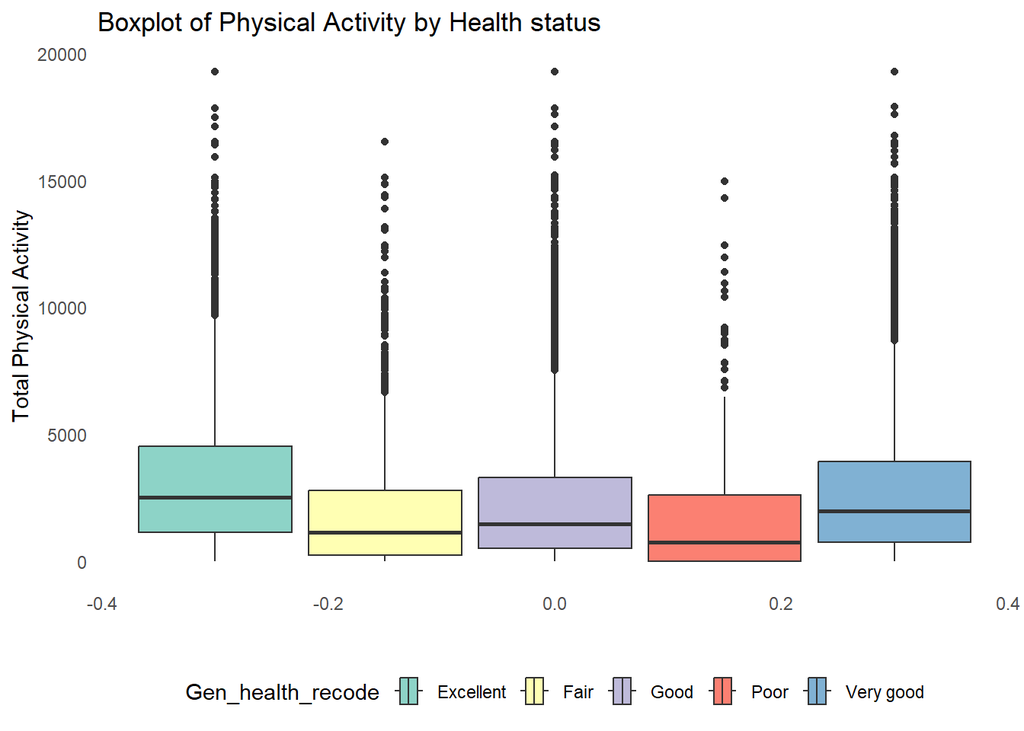

```r
ggplot(can_path_merged, aes(x = PA_total_short, fill = Gen_health_recode))+
  geom_boxplot()+
  scale_fill_brewer(palette = "Set3")+
  coord_flip()+
  labs(title = "Boxplot of Physical Activity by Health status",
       x = "Total Physical Activity",
       y= "")+
  theme_minimal()+
  theme(panel.grid.major = element_blank(), panel.grid.minor = element_blank(),
        legend.position = "bottom")
```

This boxplot displays the total physical activity by health status. The “Excellent” and “Very good” categories of health have a little higher medians, while “Poor” has the lowest. All groups have similar interquartile ranges, with outliers indicating high activity levels across categories. Physical activity levels overlap, suggesting health differences involve factors beyond activity alone.